# Praca domowa 2

Jędrzej Kwaśny

| Zmienna | Opis |
| --- | --- |
| **gender** | płeć |
| **race.ethnicity** | pochodzenie etniczne |
| **parental.level.of.education** | wykształcenie rodziców |
| **lunch** | jaki obiad jedli uczniowie w dniu egzaminu |
| **test.preparation.course** | czy uczeń odbył kurs przygotowujący |
| **math.score** | wynik egzaminu z matematyki |
| **reading.score** | wynik egzaminu z czytania |
| **writing.score** | wynik egzaminu z pisania |

Zadanie 1

Jak wyglądają rozkłady wyników uczniów z trzech przedmiotów (matematyka, czytanie, pisanie)?

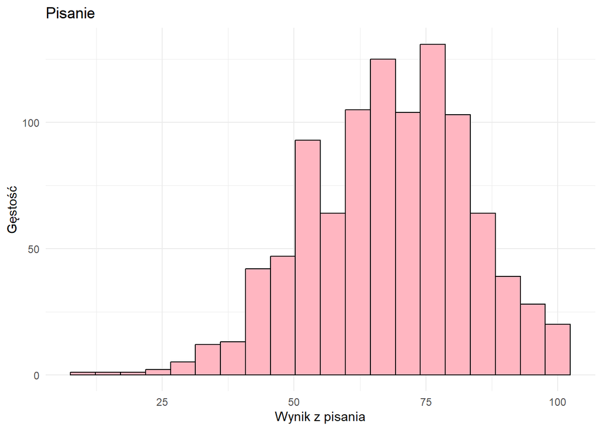

```r
# Tu umieść kod do wygenerowania odpowiedzi do zadania.

math <- ggplot(df, aes(x = math.score)) +
  geom_histogram(aes(y = after_stat(count)), bins = 20, colour = "black", fill = "lightblue") +
  labs(x = "Wynik z matematyki", y = "Ilość", title="Matematyka") +
  theme_minimal()

read <- ggplot(df, aes(x = reading.score)) +
  geom_histogram(aes(y = after_stat(count)), bins = 20, colour = "black", fill = "lightgreen") +
  labs(x = "Wynik z czytania", y = "Gęstość", title="Czytanie") +
  theme_minimal()

write <- ggplot(df, aes(x = writing.score)) +
  geom_histogram(aes(y = after_stat(count)), bins = 20, colour = "black", fill = "lightpink") +
  labs(x = "Wynik z pisania", y = "Gęstość", title="Pisanie") +
  theme_minimal()



write
```

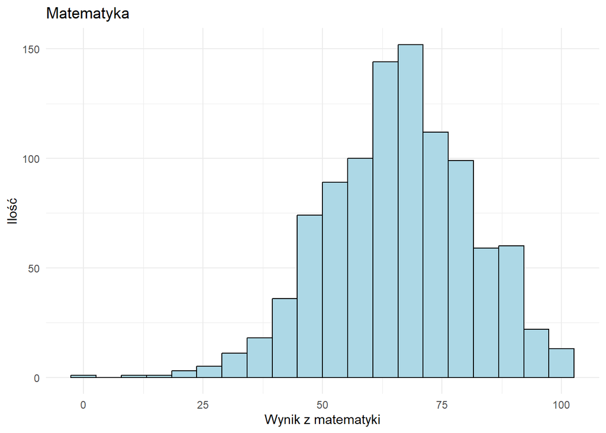

```r
math
```

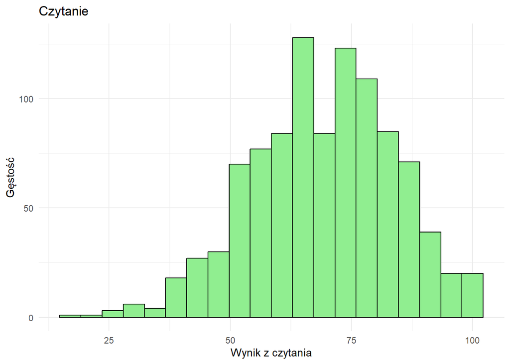

```r
read
```

Zadanie 2

Czy istnieje zauważalna różnica w wynikach między uczniami i uczennicami?

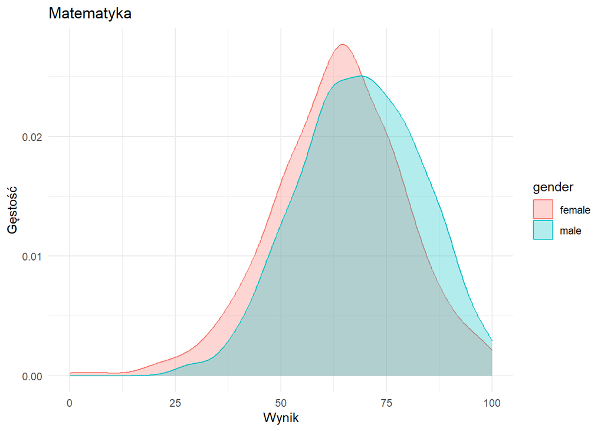

```r
##Tu umieść kod do wygenerowania odpowiedzi do zadania.

df1<-df[df$gender=="female",]
df2<-df[df$gender=="male",]

math2<-ggplot(df, aes(x = math.score, fill = gender, color = gender)) +
  geom_density(alpha = 0.3) +
  labs(x = "Wynik",
       y = "Gęstość", title="Matematyka") +
  theme_minimal()
write2<-ggplot(df, aes(x = writing.score, fill = gender, color = gender)) +
  geom_density(alpha = 0.3) +
  labs(x = "Wynik",
       y = "Gęstość", title="Pisanie") +
  theme_minimal()
read2<-ggplot(df, aes(x = reading.score, fill = gender, color = gender)) +
  geom_density(alpha = 0.3) +
  labs(x = "Wynik",
       y = "Gęstość", title="Czytanie") +
  theme_minimal()

math2
```

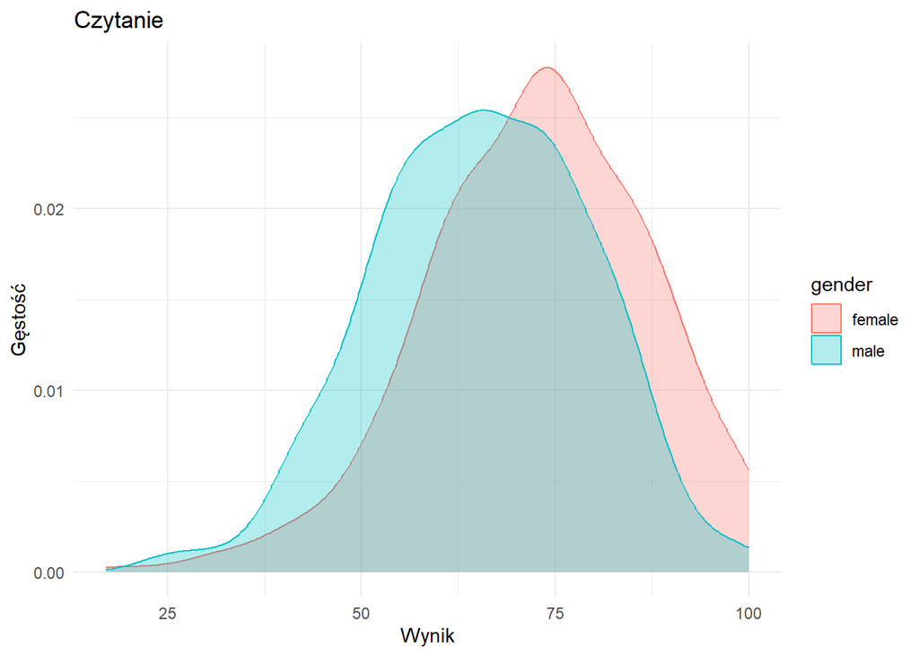

```r
read2
```

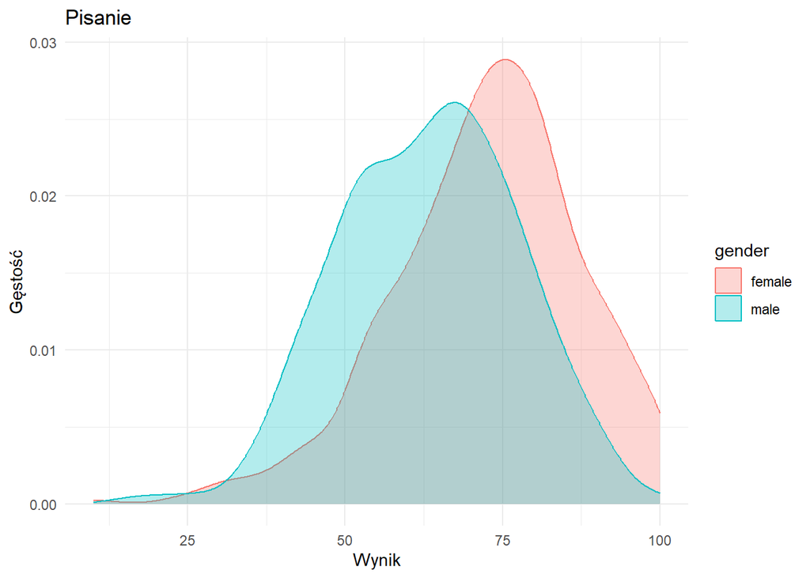

```r
write2
```

**Komentarz:** Uczniowie poradzili sobie lepiej z matematyką, osiągając srednią wyższą o 5 punktów procentowych, a wykres wyników uczniów jest skierowany lekko w prawo wzdlędem wyników uczennic. Wyniki z czytania i pisania są natomiast odwrotne i uczennice odniosły wyniki lepsze od uczniów i wykresy uczennic są skierowane w prawo względem wykresów wyników uczniów.

Zadanie 3

Czy uczniowie, którzy ukończyli kurs przygotowawczy, osiągają lepsze wyniki niż pozostali?

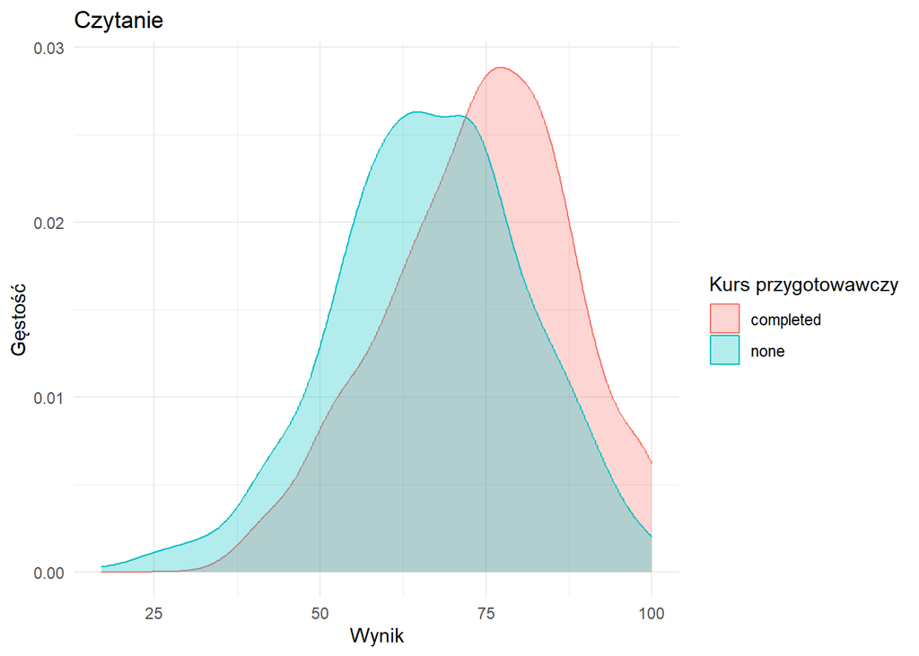

```r
# Tu umieść kod do wygenerowania odpowiedzi do zadania.


df1<-df[df$test.preparation.course=="completed",]
df2<-df[df$test.preparation.course=="none",]

math3<-ggplot(df, aes(x = math.score, fill = test.preparation.course, color = test.preparation.course)) +
  geom_density(alpha = 0.3) +
  labs(x = "Wynik",
       y = "Gęstość", fill = "Kurs przygotowawczy",  color = "Kurs przygotowawczy", title="Matematyka") +
  theme_minimal()
write3<-ggplot(df, aes(x = writing.score, fill = test.preparation.course, color = test.preparation.course)) +
  geom_density(alpha = 0.3) +
  labs(x = "Wynik",
       y = "Gęstość", fill = "Kurs przygotowawczy",  color = "Kurs przygotowawczy", title="Pisanie") +
  theme_minimal()
read3<-ggplot(df, aes(x = reading.score, fill = test.preparation.course, color = test.preparation.course)) +
  geom_density(alpha = 0.3) +
  labs(x = "Wynik",
       y = "Gęstość", fill = "Kurs przygotowawczy",  color = "Kurs przygotowawczy", title="Czytanie")+

  theme_minimal()

read3
```

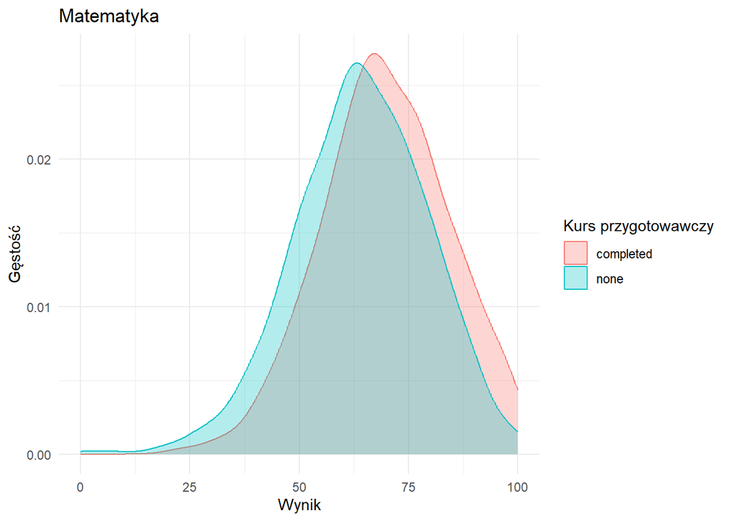

```r
math3
```

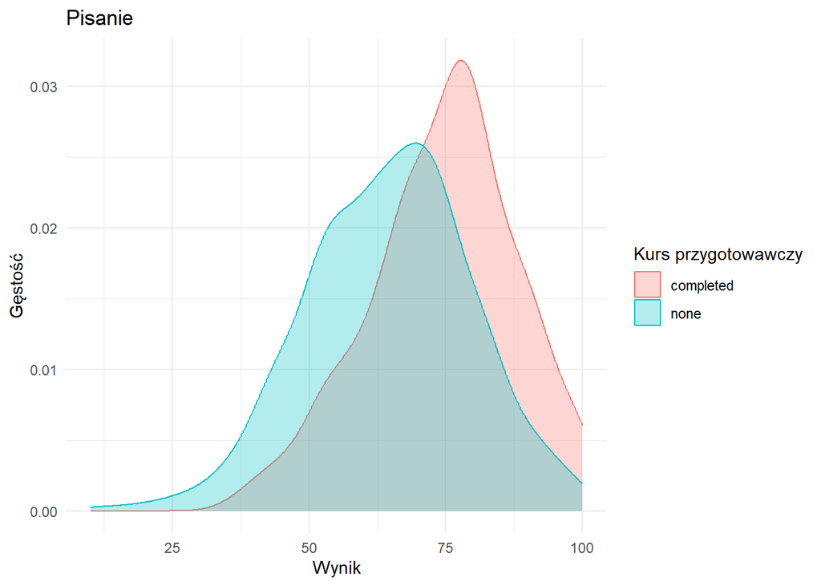

```r
write3
```

**Komentarz:**

Uczniowie którzy ukończyli kurs poradzili sobie lepiej. Najmniejsza różnica jest widoczna przy wynikach z matematyki gdzie wykres wyników uczniów którzy ukończyli kurs jest tylko lekko odchylony w prawo względem tych, którzy nie ukończyli kursu. Kurs o wiele lepiej przygotował do testów z czytania i pisania, przy czym różnica jest największa w wynikach z testu z pisania jest wyraźnie zauważalna na wykresie, Zauważyć można o wiele mniej niskich wyników, o wiele więcej wyników w granicahc 75-80% a także 2 razy więcej wyników w okolicach 100%, a różnica średnich wynosi 10 punktów procentowych.

Zadanie 4

Jaki jest związek między poziomem wykształcenia rodziców a średnimi wynikami uczniów?

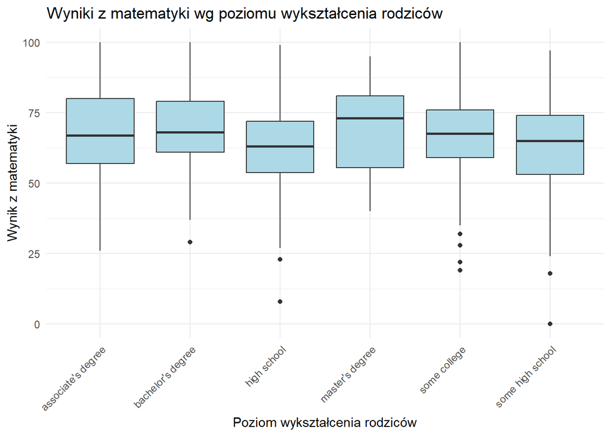

```r
# Tu umieść kod do wygenerowania odpowiedzi do zadania.

df4<-df %>%
  group_by(parental.level.of.education) %>%
  summarise(
    mean_math = mean(math.score, na.rm = TRUE),
    mean_reading = mean(reading.score, na.rm = TRUE),
    mean_writing = mean(writing.score, na.rm = TRUE))



a<-ggplot(df, aes(x = parental.level.of.education, y = math.score)) +
  geom_boxplot(fill = "lightblue") +
  labs(title = "Wyniki z matematyki wg poziomu wykształcenia rodziców",
       x = "Poziom wykształcenia rodziców",
       y = "Wynik z matematyki") +
  theme_minimal() +
  theme(axis.text.x = element_text(angle = 45, hjust = 1))
b<-df %>%
  group_by(parental.level.of.education) %>%
  summarise(mean_math = mean(math.score, na.rm = TRUE)) %>%
  ggplot(aes(x = reorder(parental.level.of.education, mean_math), y = mean_math)) +
  geom_col() +
  labs(title = "Średni wynik z matematyki wg poziomu wykształcenia rodziców",
       x = "", y = "Średni wynik") +
  theme_minimal()
a
```

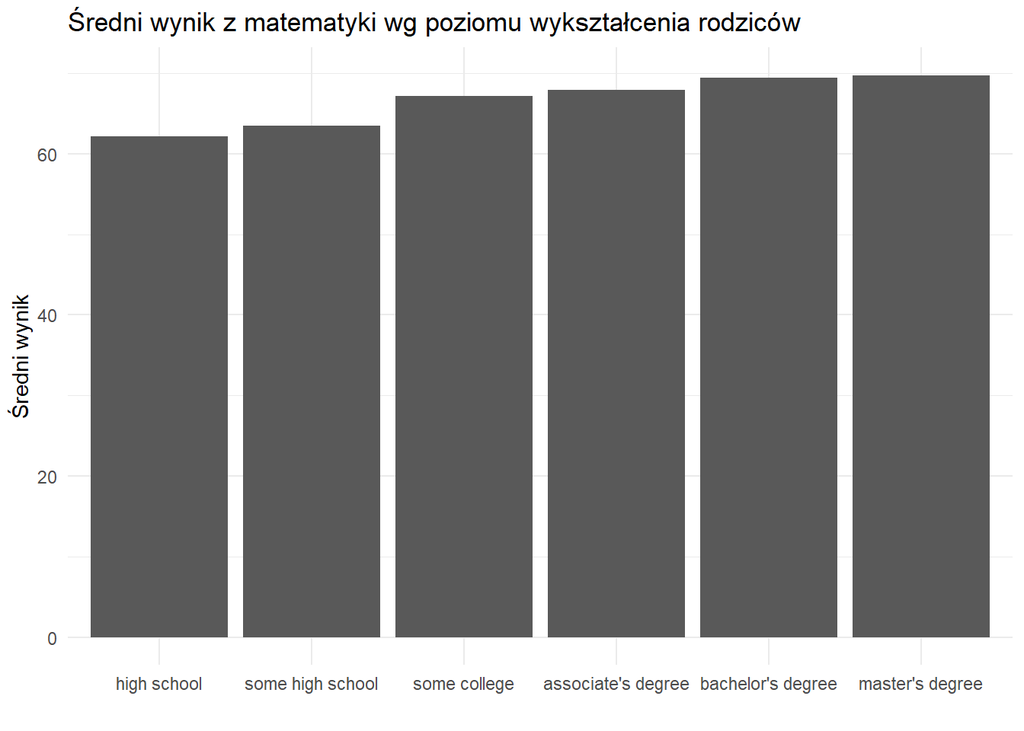

```r
b
```

**Komentarz:**

Zauważalny jest trend większych średnich wyników wraz z wyższym poziomem wykształcenia rodziców, lecz nie są to duże różnice. Różnica pomiędzy najniższą średnią (z wyników uczniów których rodzice ukończyli tylko szkołę średnią), a najwyższą (z wyników uczniów których rodzice posiadają tytul magistra) to zaledwie 7 punktów procentowych.

Zadanie 5

Czy płeć i wykształcenie rodzica wpływa na wynik z matematyki?

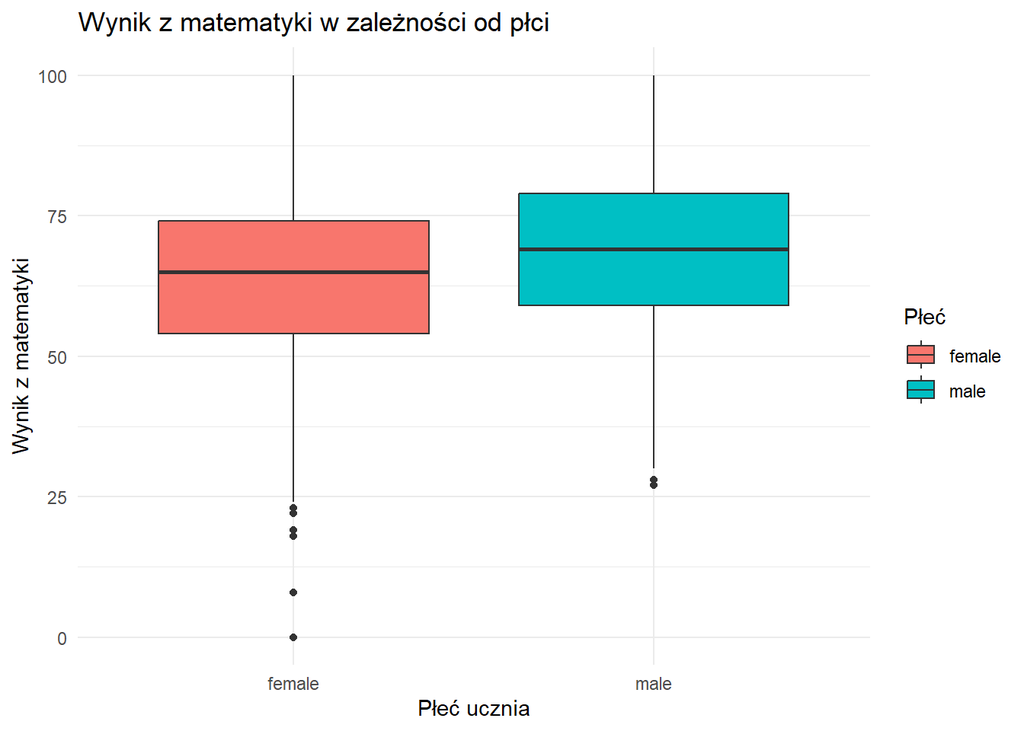

```r
# Tu umieść kod do wygenerowania odpowiedzi do zadania.


a<-ggplot(df, aes(x = gender, y = math.score, fill = gender)) +
  geom_boxplot() +
  labs(title = "Wynik z matematyki w zależności od płci",
       x = "Płeć ucznia",
       y = "Wynik z matematyki", fill = "Płeć") +
  theme_minimal()

b<-ggplot(df, aes(x = parental.level.of.education, y = math.score, fill = parental.level.of.education)) +
  geom_boxplot() +
  labs(title = "Wynik z matematyki a wykształcenie rodzica",
       x = "Wykształcenie rodzica",
       y = "Wynik z matematyki", fill = "Poziom wykształcenia rodziców") +
  theme_minimal()

c<-ggplot(df, aes(x = parental.level.of.education, y = math.score, fill = gender)) +
  geom_boxplot(position = position_dodge(width = 0.8)) +
  labs(title = "Wynik z matematyki w zależności od płci i wykształcenia rodzica",
       x = "Wykształcenie rodzica",
       y = "Wynik z matematyki",
       fill = "Płeć") +
  theme_minimal()
a
```

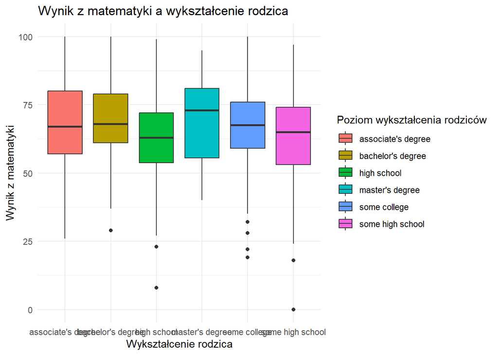

```r
b
```

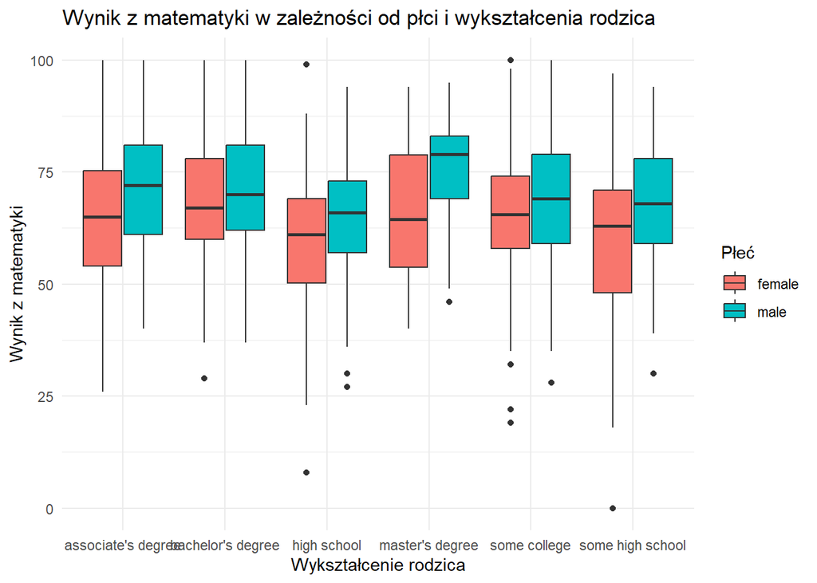

```r
c
```

**Komentarz:** Tak, zarówno płeć jak i wykształcenie rodziców wpływa na wyniki. Uczniowie osiągali nieco wyższe wyniki od uczennic, a wyższe wykształcenie rodziców również pozytywnie wpływało na wynik z matematyki.

Zadanie 6 Czy istnieje zależność między wynikami z matematyki a wynikami z czytania lub pisania?

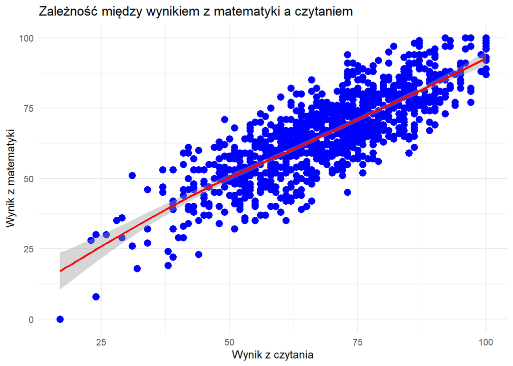

```r
# Tu umieść kod do wygenerowania odpowiedzi do zadania.

a<-ggplot(df, aes(x = reading.score, y = math.score)) +
  geom_point(color = "blue", size = 3) +
  geom_smooth(color = "red") +
  labs(title = "Zależność między wynikiem z matematyki a czytaniem",
       x = "Wynik z czytania",
       y = "Wynik z matematyki") +
  theme_minimal()

b<-ggplot(df, aes(x = writing.score, y = math.score)) +
  geom_point(color = "darkgreen", size = 3) +
  geom_smooth(color = "red") +
  labs(title = "Zależność między wynikiem z matematyki a pisaniem",
       x = "Wynik z pisania",
       y = "Wynik z matematyki") +
  theme_minimal()

a
```

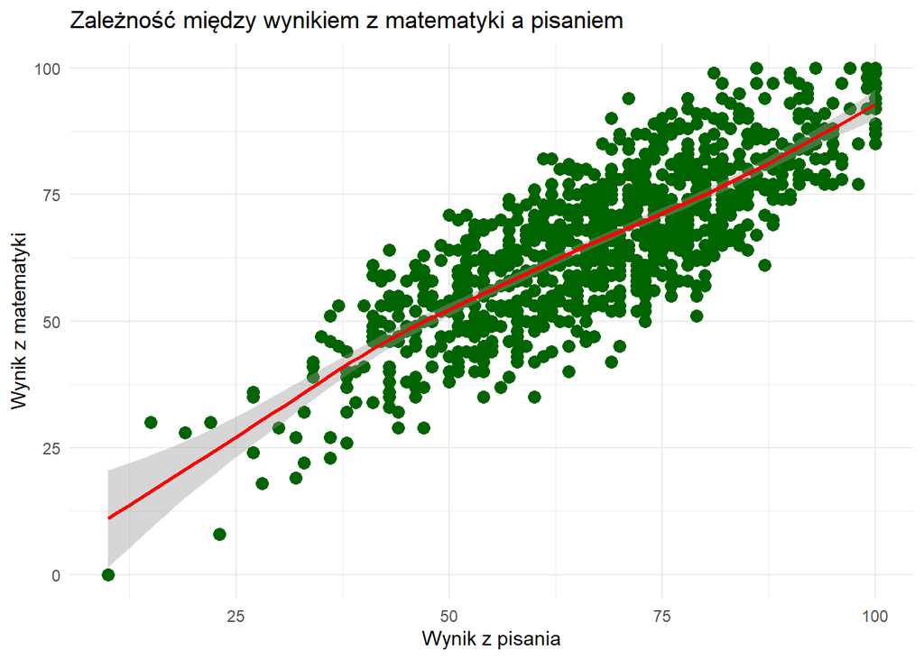

```r
b
```

**Komentarz:** Istnieje silna zależność pomiędzy wynikami z matemetyki oraz czytania i pisania. Jest ona liniowa, a jej współcznynnik w obu przypadkach wynosi około 0.8, lecz zależność między wynikami z pisania i czytania jest jeszcze większa.